# Phy 481 - Hw 11

Andrew Koren

## 1 - Current densities

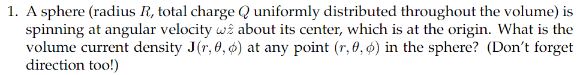

Current should scale with radius. Note that charge density $\rho = Q/V = \frac{Q}{\frac{4}{3}\pi R^3}$

$$ \mathbf J = \rho \vec v \\ \vec v = \vec \omega \times \vec r \\ = r\omega \hat z \times \hat r \\ = r \omega \sin (\theta) \hat \phi \\ \mathbf{J}(r,\theta,\phi)=\rho r \omega\sin (\theta) \hat \phi = \frac{Q}{\frac{4}{3}\pi R^3}r \omega\sin (\theta) \hat \phi $$

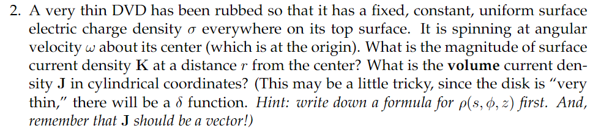

Surface current density is quite easy, and we just work backwards from that to get volume current density

$$ \mathbf{K} = \sigma \vec v \\ \vec v = \vec \omega \times \vec s = s\omega \hat \phi \\ \mathbf{K}(s,\phi) = \sigma s\omega \hat \phi \\ \mathbf{J}(s,\phi,z) = \sigma s\omega \hat \phi \cdot\delta(z) $$

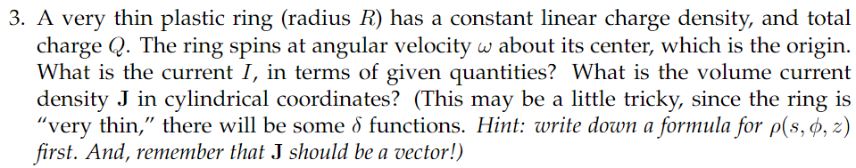

This is an E&M question!

$$ \mathbf I(\phi) = \frac{Q}{2\pi R} \vec v = \frac{Q\omega}{2\pi} \hat \phi \\ $$ For $\mathbf{J}$, simply divide by the size of the ring and zero-in using $\delta$ functions $$ L = 2\pi R \\ \mathbf{J}(s,\phi,z) = \frac{Q}{2\pi R} \omega R \hat \phi \cdot \delta(z)\delta(s-R)\\ =\frac{Q\omega}{2\pi} \hat \phi \cdot \delta(z)\delta(s-R) $$

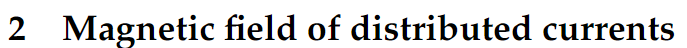

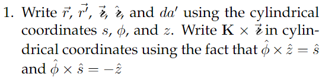

Unfortunately I do not have the script-R package $$ \vec r = r \hat r = z \hat z\\ \vec r' = s' \hat s \\ \vec{\mathcal{R}} = z \hat z - s' \hat s \\ \hat{\mathcal{R}} = \frac{\vec{\mathcal{R}}}{|\mathcal{R}|} = \frac{z \hat z - s' \hat s}{\sqrt{z^2+s'^2}}\\ da' = sds d\phi $$ Using our previously found value for $\mathbf K$ we have $$ \mathbf K \times \vec{\mathcal{R}} = \sigma s' \omega \hat \phi \times \left(z \hat z - s' \hat s\right) $$ The cross product is distributive, so we have $$ =\sigma s' \omega \hat \phi \times \left(z \hat z - s' \hat s\right)\\ =\left(zs' \sigma \omega \hat \phi \times \hat z\right) - \left(s'^2 \sigma \omega \hat \phi \times\hat s\right) \\ =\left(zs' \sigma \omega \hat s\right) + \left(s'^2 \sigma \omega \hat z\right) \\ =s' \sigma \omega\left(z \hat s + s' \hat z\right) $$

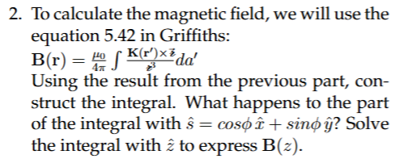

We'll drop the prime notation since it is redundant $$ \mathbf B(r) = \frac{\mu_0}{4\pi} \int_0^R\int_0^{2\pi} \frac{s\sigma \omega \left(z\hat s + s\hat z \right)}{\sqrt{z^2+s^2}^3} sd\phi ds \\ = \frac{\mu_0\sigma \omega }{4\pi} \int_0^R\int_0^{2\pi} \frac{s^2z\hat s }{\sqrt{z^2+s^2}^3} d\phi ds + \frac{\mu_0\sigma \omega }{4\pi}\int_0^R\int_0^{2\pi} \frac{s^3\hat z}{\sqrt{z^2+s^2}^3} d\phi ds \\ $$ Since $\hat s$ has $\phi$ dependence, we'll convert to $\hat x$ and $\hat y$ terms $$ \frac{\mu_0\sigma \omega }{4\pi} \int_0^R\int_0^{2\pi} s^2\frac{z\hat s }{\sqrt{z^2+s^2}^3} d\phi ds = \frac{\mu_0\sigma \omega }{4\pi} \int_0^R\int_0^{2\pi} s^2z\frac{ \cos\phi \hat x + \sin\phi \hat y }{\sqrt{z^2+s^2}^3} d\phi ds $$

The integral of both $\sin(\phi)$ and $\cos(\phi) $ come out to zero, resulting in the $\hat s$ portion of the integral zeroing out

$$ \mathbf B(z) = \frac{\mu_0\sigma \omega }{4\pi}\int_0^R\int_0^{2\pi} \frac{s^3\hat z}{\sqrt{z^2+s^2}^3} d\phi ds\\ = \frac{\mu_0\sigma \omega }{2}\hat z\int_0^R \left(\frac{s}{\sqrt{z^2+s^2}}\right)^3 ds $$ Via my friend sympy we have $$ B_z(z) = \frac{\mu_0\sigma \omega }{2}\left(\frac{R^2+2z^2}{\sqrt{R^2+z^2}} - \frac{2z^2}{|z|} \right) $$

```python
import sympy as sp
from sympy import * #makes display() wor

z,s,R = sp.symbols('z,s,R', positive=True)

eqn = s**3/sp.sqrt(z**2+s**2)**3 #integrand

result = sp.integrate(eqn, s)
display(result) #indefinite integral

result.subs(s, R) - result.subs(s, 0) #apply bounds
```

$\displaystyle \frac{s^{2}}{\sqrt{s^{2} + z^{2}}} + \frac{2 z^{2}}{\sqrt{s^{2} + z^{2}}}$

$\displaystyle \frac{R^{2}}{\sqrt{R^{2} + z^{2}}} + \frac{2 z^{2}}{\sqrt{R^{2} + z^{2}}} - 2 z$

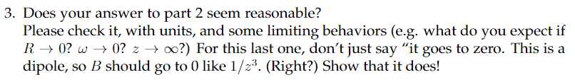

Units: want $[B]=T=\frac{kg}{C\cdot s}$

$$ [\mu_0] = \frac{kg\cdot m}{s^2}\frac{s^2}{C^2} \\ [\sigma] = \frac{C}{m^2} \\ [\omega] = \frac{1}{s} \\ $$ Note that $[\hat z]=m$ since it provides a distance component $$ [B_z(z)] = \frac{kg\cdot m}{C^2}\frac{C}{m^2}\frac{1}{s}m =\frac{kg}{C\cdot s} = [B] $$

$R \rightarrow 0$: both $2z^2$ terms cancel out and we have zero magnetic field.

$\omega \rightarrow 0$: the omega term is a prefactor, so zeroing it out turns off the magnetic field linearly

$z \rightarrow \infty$: Similar ot $R \rightarrow 0$

Lets rewrite it so that the $R$ terms disappear, and for simplicity use $a=\mu_0 \sigma \omega$. Note that $z>0$ $$ B_z(z) = \frac{a}{2}\frac{R^2}{z\sqrt{1+\frac{R^2}{z^2}}} + \frac{a}{2}\frac{2z^2}{z\sqrt{\frac{R^2}{z^2}+1}} - \frac{a}{2}\frac{2z^2}{z} $$ Since $R/z\rightarrow 0$ in the limit, we have $$ \lim_{z \rightarrow \infty} B_z(z) = 0 + a\frac{z}{\sqrt{1}} - az = az-az $$

There's no denying this goes to zero, but it doesn't describe *how* it goes to zero. Let's try to group all the z terms together.

$$ B_z(z) = \frac{a}{2}\frac{R^2+2z^2}{z\sqrt{\frac{R^2}{z^2}+1}} - az = az\left[ \frac{\frac{R^2}{2z^2}+1}{\sqrt{\frac{R^2}{z^2}+1}} - 1\right] $$

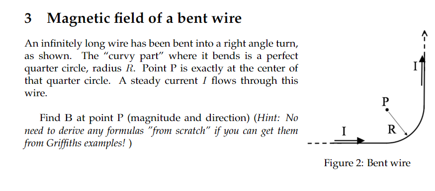

This is simple. We just use the formula for an infinte line and 1/4 the field of a ring of current.

$$B_{\text{line}} = \frac{\mu_0 I}{2\pi R}$$

Using RHR we know there is no x or y component, so we can treat the two separate straight sections as one straight wire. They have equivalent affects at P.

$$B_{\text{loop}} = \frac{\mu_0 I}{2R}$$

Again, we can use RHR to know there are no added complexities from only using 1/4 of a loop, so this simply contributes 1/4 of the z component of a loop around $P$. This gives us

$$ B(P) = \frac{\mu_0 I}{2\pi R} + \frac{\mu_0 I}{8R} $$

Where $B$ points out of the page for current flowing from the bottom left (again, RHR).

Coding:

ak_HW09_MotionOfChargeInMagneticField.ipynb